# Bayesian Inference with NIMBLE

# Simple linear regression in NIMBLE

```r
library(nimble)
```

# Simulate data

$$\begin{align*}
y_i \sim N(\beta_0 + \beta_1 x_i, \sigma^2)
\end{align*}$$

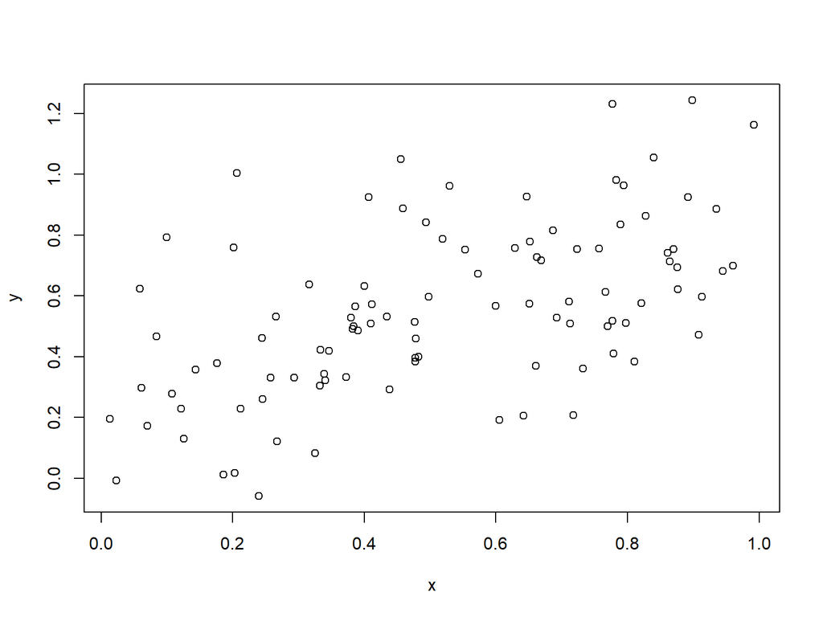

```r
set.seed(1)
n <- 100
x <- runif(n)
b0_true <- 0.3
b1_true <- 0.5
sigma_true <- 0.25
y <- rnorm(n, b0_true + b1_true*x, sigma_true)

plot(x, y)
```

# NIMBLE model syntax

```r
lmCode <- nimbleCode({

    # likelihood
    for(i in 1:n) {
        mu[i] <- b0 + b1*x[i]
        y[i] ~ dnorm(mu[i], sd = sigma)
    }

    # priors
    b0 ~ dnorm(0, sd = 100)
    b1 ~ dnorm(0, sd = 100)
    sigma ~ dunif(0, 100)

})
```

# Sampling from the posterior (easy method)

After writing the model, we can obtain samples from the posterior. The most straightforward method for this is to use the nimbleMCMC function. This uses the default MCMC algorithm.

```r
dataList <- list(y = y)
constantsList <- list(n = n, x = x)
initsList <- list(b0 = 1, b1 = 0, sigma = 1)

system.time({
    samples <- nimbleMCMC(lmCode,
                          data = dataList,
                          constants = constantsList,
                          inits = initsList,
                          niter = 10000)
})
```

```
## Defining model
```

```
## Building model
```

```
## Setting data and initial values
```

```
## Running calculate on model
##   [Note] Any error reports that follow may simply reflect missing values in model variables.
```

```
## Checking model sizes and dimensions
```

```
## Checking model calculations
```

```
## Compiling
##   [Note] This may take a minute.
##   [Note] Use 'showCompilerOutput = TRUE' to see C++ compilation details.
```

```
## running chain 1...
```

```
## |-------------|-------------|-------------|-------------|
## |-------------------------------------------------------|
```

```
##    user  system elapsed
##    4.49    0.05   23.89
```

```r
head(samples)
```

```
##             b0           b1     sigma
## [1,] 0.5995468  0.048915002 0.6819316
## [2,] 0.4658218  0.082143966 0.6819316
## [3,] 0.5801855  0.008914881 0.6819316
## [4,] 0.6773847 -0.016997270 0.4432845
## [5,] 0.6102514  0.103235323 0.4432845
## [6,] 0.5988616  0.033734215 0.4432845
```

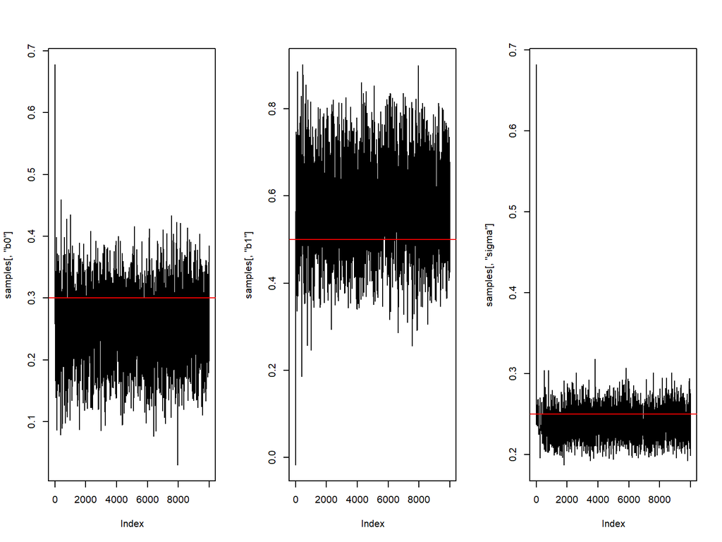

```r
par(mfrow = c(1,3))
plot(samples[,'b0'], type = 'l')
abline(h = b0_true, col = 'red')
plot(samples[,'b1'], type = 'l')
abline(h = b1_true, col = 'red')
plot(samples[,'sigma'], type = 'l')
abline(h = sigma_true, col = 'red')
```

# Sampling from the posterior (customizable method)

We can also obtain samples using a longer method which provides the ability to customize the MCMC algorithm. Using this method, there are 5 steps:

1. Build the nimbleModel object

```r
### create nimble model object
lmModel <- nimbleModel(lmCode,
                       data = dataList,
                       constants = constantsList,
                       inits = initsList)
```

```
## Defining model
```

```
## Building model
```

```
## Setting data and initial values
```

```
## Running calculate on model
##   [Note] Any error reports that follow may simply reflect missing values in model variables.
```

```
## Checking model sizes and dimensions
```

2. Create the MCMC configuration object

```r
lmConfigure <- configureMCMC(lmModel)
```

```
## ===== Monitors =====
## thin = 1: b0, b1, sigma
## ===== Samplers =====
## RW sampler (1)
##   - sigma
## conjugate sampler (2)
##   - b0
##   - b1
```

3. Build the MCMC object from the configuration

```r
lmMCMC <- buildMCMC(lmConfigure)
```

4. Compile the model and MCMC in C++

```r
lmCompiled <- compileNimble(lmModel, lmMCMC)
```

```
## Compiling
##   [Note] This may take a minute.
##   [Note] Use 'showCompilerOutput = TRUE' to see C++ compilation details.
```

5. Run the MCMC to obtain samples

```r
samples2 <- runMCMC(lmCompiled$lmMCMC, niter = 10000)
```

```
## running chain 1...
```

```
## |-------------|-------------|-------------|-------------|
## |-------------------------------------------------------|
```

```r
head(samples2)
```

```
##             b0          b1     sigma
## [1,] 0.6356426 -0.19927512 0.2058378
## [2,] 0.6711474 -0.03573294 0.2058378
## [3,] 0.5683179  0.11255896 0.2058378
## [4,] 0.4993390  0.17973185 0.2058378
## [5,] 0.4670538  0.24639678 0.2058378
## [6,] 0.4177056  0.35017402 0.2058378
```

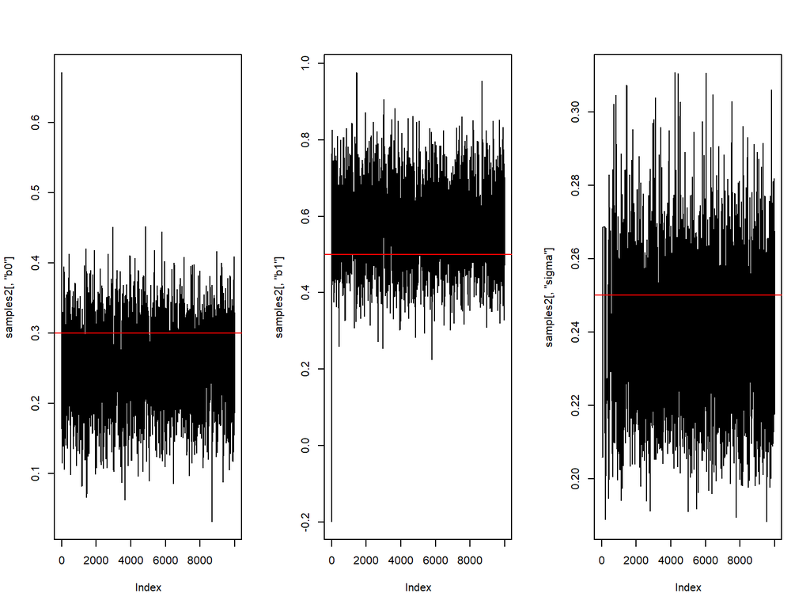

```r
par(mfrow = c(1,3))
plot(samples2[,'b0'], type = 'l')
abline(h = b0_true, col = 'red')
plot(samples2[,'b1'], type = 'l')
abline(h = b1_true, col = 'red')
plot(samples2[,'sigma'], type = 'l')
abline(h = sigma_true, col = 'red')
```

# Customizing the MCMC

Using the customizable method, we can customize the MCMC. For example, we could use a slice sampler instead of a random walk sampler for sigma.

```r
lmConfigure$removeSamplers('sigma')
lmConfigure$addSampler('sigma',
                       type = 'slice')

lmConfigure
```

```
## ===== Monitors =====
## thin = 1: b0, b1, sigma
## ===== Samplers =====
## slice sampler (1)
##   - sigma
## conjugate sampler (2)
##   - b0
##   - b1
```

```r
lmMCMC <- buildMCMC(lmConfigure)

lmCompiled <- compileNimble(lmModel, lmMCMC)
```

```
## Compiling
##   [Note] This may take a minute.
##   [Note] Use 'showCompilerOutput = TRUE' to see C++ compilation details.
```

```r
samples3 <- runMCMC(lmCompiled$lmMCMC, niter = 10000)
```

```
## running chain 1...
```

```
## |-------------|-------------|-------------|-------------|
## |-------------------------------------------------------|
```

```r
head(samples3)
```

```
##             b0            b1     sigma
## [1,] 0.6787148 -0.3638908964 0.9216053
## [2,] 0.7365170 -0.1490717770 0.6649148
## [3,] 0.7177710 -0.3103867234 0.3220480
## [4,] 0.6798399 -0.1185862710 0.3152380
## [5,] 0.6315467  0.0008731193 0.3052329
## [6,] 0.5419239  0.0398050778 0.2996829
```

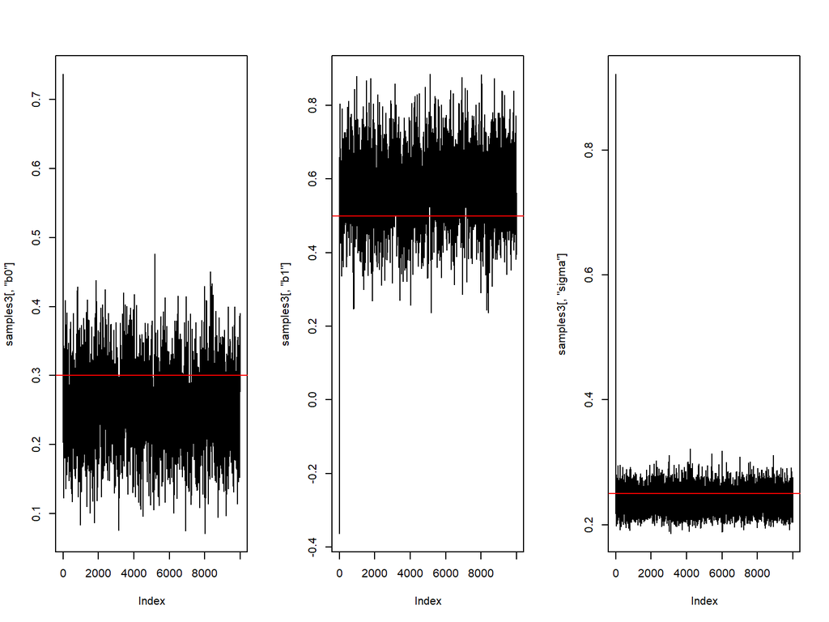

```r
par(mfrow = c(1,3))
plot(samples3[,'b0'], type = 'l')
abline(h = b0_true, col = 'red')
plot(samples3[,'b1'], type = 'l')
abline(h = b1_true, col = 'red')
plot(samples3[,'sigma'], type = 'l')
abline(h = sigma_true, col = 'red')
```

# nimbleModels are objects

The nimbleModel object contains the current state of the model parameters.

```r
lmModel$b0
```

```
## [1] 1
```

```r
lmModel$b1
```

```
## [1] 0
```

```r
lmModel$sigma
```

```
## [1] 1
```

```r
lmModel$getLogProb()
```

```
## [1] -121.3661
```

```r
lmModel$calculate()
```

```
## [1] -121.3661
```

```r
sum(dnorm(y, mean = lmModel$b0 + lmModel$b1*x, sd = lmModel$sigma, log = T)) +
    dnorm(lmModel$b0, 0, 100, log = T) +
    dnorm(lmModel$b1, 0, 100, log = T) +
    dunif(lmModel$sigma, 0, 100, log = T)
```

```
## [1] -121.3661
```

When calculate() is called, the stored value of the model is updated (if parameter values have changed), while getLogProb() simply returns the cached value.

```r
lmModel$b0
```

```
## [1] 1
```

```r
lmModel$b0 <- 2

lmModel$getLogProb()
```

```
## [1] -121.3661
```

```r
lmModel$calculate()
```

```
## [1] -215.9134
```

```r
lmModel$getLogProb()
```

```
## [1] -215.9134
```

Another useful method is getDependencies(), which returns all nodes that are dependent on the input argument.

```r
lmModel$getDependencies('b0')
```

```
##   [1] "b0"      "mu[1]"   "mu[2]"   "mu[3]"   "mu[4]"   "mu[5]"   "mu[6]"
##   [8] "mu[7]"   "mu[8]"   "mu[9]"   "mu[10]"  "mu[11]"  "mu[12]"  "mu[13]"
##  [15] "mu[14]"  "mu[15]"  "mu[16]"  "mu[17]"  "mu[18]"  "mu[19]"  "mu[20]"
##  [22] "mu[21]"  "mu[22]"  "mu[23]"  "mu[24]"  "mu[25]"  "mu[26]"  "mu[27]"
##  [29] "mu[28]"  "mu[29]"  "mu[30]"  "mu[31]"  "mu[32]"  "mu[33]"  "mu[34]"
##  [36] "mu[35]"  "mu[36]"  "mu[37]"  "mu[38]"  "mu[39]"  "mu[40]"  "mu[41]"
##  [43] "mu[42]"  "mu[43]"  "mu[44]"  "mu[45]"  "mu[46]"  "mu[47]"  "mu[48]"
##  [50] "mu[49]"  "mu[50]"  "mu[51]"  "mu[52]"  "mu[53]"  "mu[54]"  "mu[55]"
##  [57] "mu[56]"  "mu[57]"  "mu[58]"  "mu[59]"  "mu[60]"  "mu[61]"  "mu[62]"
##  [64] "mu[63]"  "mu[64]"  "mu[65]"  "mu[66]"  "mu[67]"  "mu[68]"  "mu[69]"
##  [71] "mu[70]"  "mu[71]"  "mu[72]"  "mu[73]"  "mu[74]"  "mu[75]"  "mu[76]"
##  [78] "mu[77]"  "mu[78]"  "mu[79]"  "mu[80]"  "mu[81]"  "mu[82]"  "mu[83]"
##  [85] "mu[84]"  "mu[85]"  "mu[86]"  "mu[87]"  "mu[88]"  "mu[89]"  "mu[90]"
##  [92] "mu[91]"  "mu[92]"  "mu[93]"  "mu[94]"  "mu[95]"  "mu[96]"  "mu[97]"
##  [99] "mu[98]"  "mu[99]"  "mu[100]" "y[1]"    "y[2]"    "y[3]"    "y[4]"
## [106] "y[5]"    "y[6]"    "y[7]"    "y[8]"    "y[9]"    "y[10]"   "y[11]"
## [113] "y[12]"   "y[13]"   "y[14]"   "y[15]"   "y[16]"   "y[17]"   "y[18]"
## [120] "y[19]"   "y[20]"   "y[21]"   "y[22]"   "y[23]"   "y[24]"   "y[25]"
## [127] "y[26]"   "y[27]"   "y[28]"   "y[29]"   "y[30]"   "y[31]"   "y[32]"
## [134] "y[33]"   "y[34]"   "y[35]"   "y[36]"   "y[37]"   "y[38]"   "y[39]"
## [141] "y[40]"   "y[41]"   "y[42]"   "y[43]"   "y[44]"   "y[45]"   "y[46]"
## [148] "y[47]"   "y[48]"   "y[49]"   "y[50]"   "y[51]"   "y[52]"   "y[53]"
## [155] "y[54]"   "y[55]"   "y[56]"   "y[57]"   "y[58]"   "y[59]"   "y[60]"
## [162] "y[61]"   "y[62]"   "y[63]"   "y[64]"   "y[65]"   "y[66]"   "y[67]"
## [169] "y[68]"   "y[69]"   "y[70]"   "y[71]"   "y[72]"   "y[73]"   "y[74]"
## [176] "y[75]"   "y[76]"   "y[77]"   "y[78]"   "y[79]"   "y[80]"   "y[81]"
## [183] "y[82]"   "y[83]"   "y[84]"   "y[85]"   "y[86]"   "y[87]"   "y[88]"
## [190] "y[89]"   "y[90]"   "y[91]"   "y[92]"   "y[93]"   "y[94]"   "y[95]"
## [197] "y[96]"   "y[97]"   "y[98]"   "y[99]"   "y[100]"
```

```r
depNodes <- lmModel$getDependencies('b0')
lmModel$getLogProb(depNodes)
```

```
## [1] -205.7841
```

```r
sum(dnorm(lmModel$y, mean = lmModel$b0 + lmModel$b1*x, sd = lmModel$sigma, log = T)) +
    dnorm(lmModel$b0, 0, 100, log = T)
```

```
## [1] -205.7841
```

# Writing a custom sampler

We can use these methods to write a custom sampler function.

For example, we could create an independence sampler for sigma, where each proposed value is a random draw from the prior a Uniform(0, 100) distribution.

```r
indSampler <- nimbleFunction(
    name = 'indSampler',                         # Convenient for class name of R reference class and generated C++ class
    contains = sampler_BASE,                     # There is a simple class inheritance system.
    setup = function(model, mvSaved, target, control) {                 # REQUIRED setup arguments
        scale <- if(!is.null(control$scale)) control$scale else 1         # Typical extraction of control choices
        calcNodes <- model$getDependencies(target)                        # Typical query of model structure
    },                                                                  # setup can't return anything
    run = function() {
        currentValue <- model[[target]]                                   # extract current value
        currentLogProb <- model$getLogProb(calcNodes)                     # get log "denominator" from cached values

        proposalValue <- runif(1, 0, 100)        # generate proposal value

        model[[target]] <<- proposalValue                                 # put proposal value in model
        proposalLogProb <- model$calculate(calcNodes)                     # calculate log "numerator"
        logAcceptanceRatio <- proposalLogProb - currentLogProb            # log acceptance ratio

        accept <- decide(logAcceptanceRatio)                              # utility function to generate accept/reject decision
        if(accept)                                                        # accept: synchronize model -> mvSaved
            copy(from = model, to = mvSaved, row = 1, nodes = calcNodes, logProb = TRUE)
        else                                                              # reject: synchronize mvSaved -> model
            copy(from = mvSaved, to = model, row = 1, nodes = calcNodes, logProb = TRUE)
    },
    methods = list(                              # required method for sampler_BASE base class
        reset = function() {}
    )
)
```

Then we can modify our MCMC configuration to use this sampler

```r
lmConfigure$removeSamplers('sigma')
lmConfigure$addSampler('sigma',
                       type = 'indSampler')

lmConfigure
```

```
## ===== Monitors =====
## thin = 1: b0, b1, sigma
## ===== Samplers =====
## indSampler sampler (1)
##   - sigma
## conjugate sampler (2)
##   - b0
##   - b1
```

```r
lmMCMC <- buildMCMC(lmConfigure)

lmCompiled <- compileNimble(lmModel, lmMCMC)
```

```
## Compiling
##   [Note] This may take a minute.
##   [Note] Use 'showCompilerOutput = TRUE' to see C++ compilation details.
```

```r
samples4 <- runMCMC(lmCompiled$lmMCMC,
                    niter = 100000,
                    nburnin = 10000)
```

```
## running chain 1...
```

```
## |-------------|-------------|-------------|-------------|
## |-------------------------------------------------------|
```

```r
head(samples4)
```

```
##             b0        b1     sigma
## [1,] 0.2364696 0.5789427 0.2165976
## [2,] 0.2588944 0.5733801 0.2165976
## [3,] 0.2653695 0.5323176 0.2165976
## [4,] 0.2926228 0.5406597 0.2165976
## [5,] 0.2531197 0.6162933 0.2165976
## [6,] 0.2259642 0.5962085 0.2165976
```

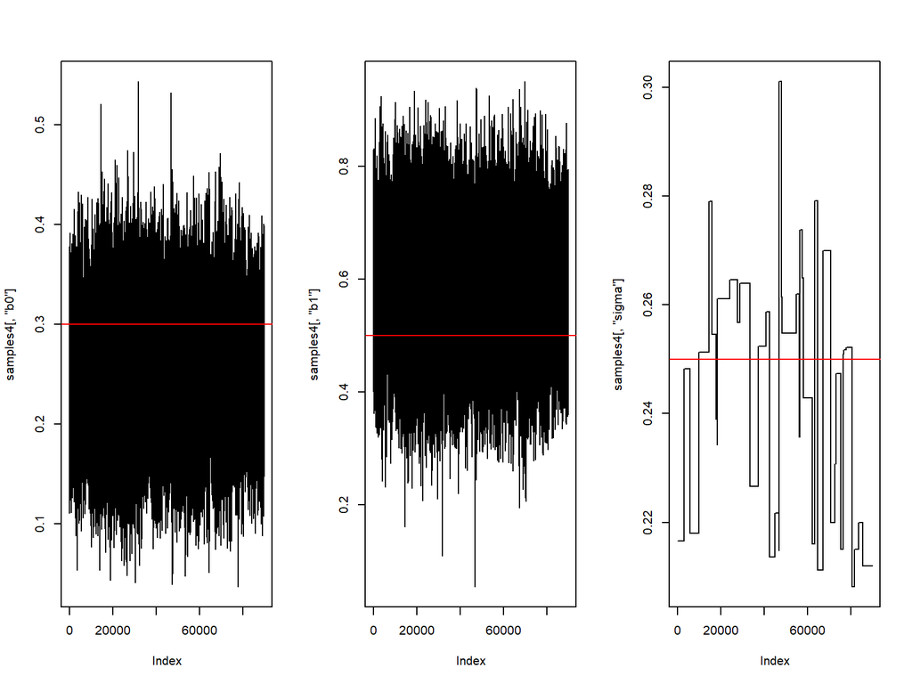

```r
par(mfrow = c(1,3))
plot(samples4[,'b0'], type = 'l')
abline(h = b0_true, col = 'red')
plot(samples4[,'b1'], type = 'l')
abline(h = b1_true, col = 'red')
plot(samples4[,'sigma'], type = 'l')
abline(h = sigma_true, col = 'red')
```

This is a very inefficient sampler.

# Simulating from a NIMBLE model

We can also use nimble models to simulate data. This is useful for simulation studies and posterior prediction.

```r
### create nimble model object without data or initial values
lmModelSim <- nimbleModel(lmCode,
                          constants = constantsList)
```

```
## Defining model
```

```
## Building model
```

```
## Running calculate on model
##   [Note] Any error reports that follow may simply reflect missing values in model variables.
```

```
## Checking model sizes and dimensions
```

```
##   [Note] This model is not fully initialized. This is not an error.
##          To see which variables are not initialized, use model$initializeInfo().
##          For more information on model initialization, see help(modelInitialization).
```

```r
# exclude data from parent nodes
parentNodes <- lmModelSim$getParents('y', stochOnly = TRUE)
nodesToSim <- lmModelSim$getDependencies(parentNodes, self = FALSE,downstream = T)

lmModelSim$b0 <- b0_true
lmModelSim$b1 <- b1_true
lmModelSim$sigma <- sigma_true

nSim <- 500

system.time({
    simDat <- matrix(NA, nrow = constantsList$n, ncol = nSim)
    for (i in 1:nSim) {
        lmModelSim$simulate(nodesToSim, includeData = TRUE)
        simDat[,i] <- lmModelSim$y
    }
})
```

```
##    user  system elapsed
##    8.16    0.04    8.84
```

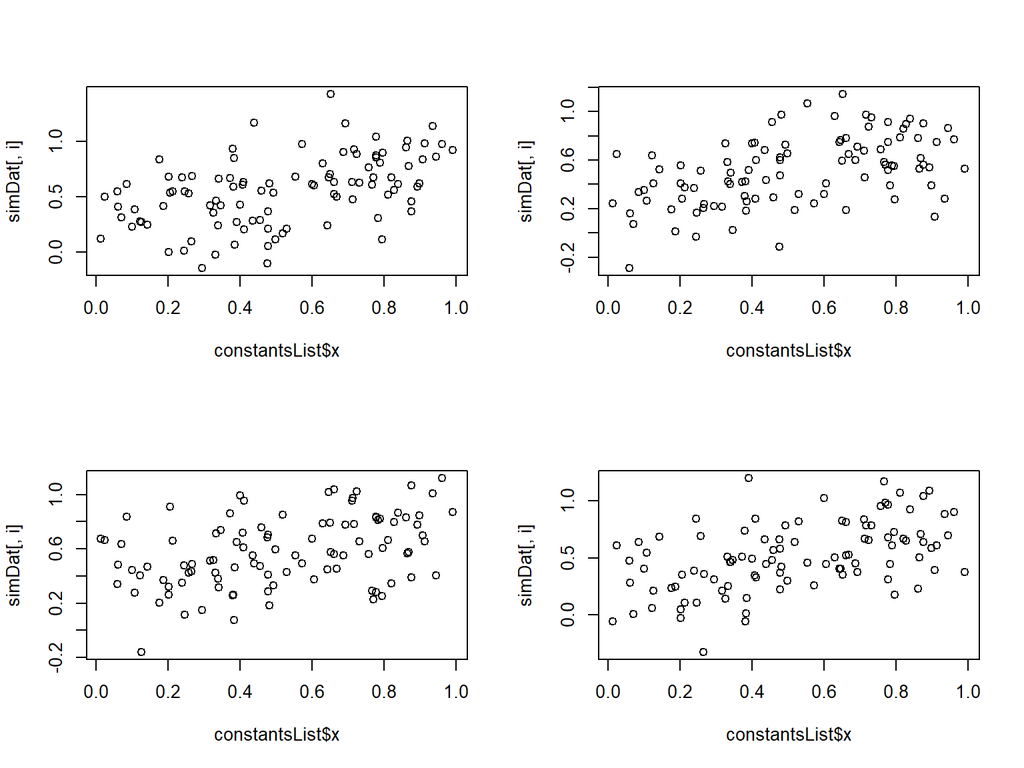

```r
par(mfrow = c(2,2))
for (i in 1:4) {
    plot(constantsList$x, simDat[,i])
}
```

Writing all of this into a function which can be compiled in C++ yields incredibly fast run times.

```r
# function to simulate from model
simulator <- nimbleFunction(
  setup = function(model, dataNodes) {

    parentNodes <- model$getParents(dataNodes, stochOnly = TRUE)
    nodesToSim <- model$getDependencies(parentNodes, self = FALSE,downstream = T)

    nData <- length(model$expandNodeNames(dataNodes, returnScalarComponents = TRUE))
  },
  run = function(nSim = double(0)) {
    simDat <- matrix(nrow = nData, ncol = nSim)
    for(i in 1:nSim) {
      model$simulate(nodesToSim, includeData = TRUE)
      simDat[, i] <- values(model, dataNodes)
    }
    return(simDat)
    returnType(double(2))
  })


compiled <- compileNimble(lmModelSim)
```

```
## Compiling
##   [Note] This may take a minute.
##   [Note] Use 'showCompilerOutput = TRUE' to see C++ compilation details.
```

```r
sim_R <- simulator(model= lmModelSim, dataNodes = 'y')
sim_C <- compileNimble(sim_R)
```

```
## Compiling
##   [Note] This may take a minute.
##   [Note] Use 'showCompilerOutput = TRUE' to see C++ compilation details.
```

```r
nSim <- 10000

system.time({
   simDat <- sim_C$run(nSim)
})
```

```
##    user  system elapsed
##    0.03    0.00    0.05
```

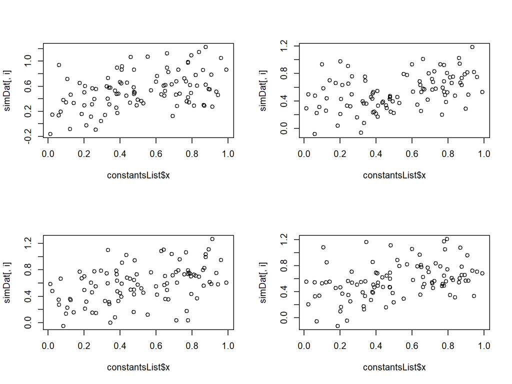

```r
par(mfrow = c(2,2))
for (i in 1:4) {
    plot(constantsList$x, simDat[,i])
}
```